# Injustice in the Justice System: Noteworthy US Incarceration Trends 1970-2018

Molly Banks

2022-11-09

## Abstract

Incarceration trends since 1970 reveal stark inequalities in the American justice system. While policy related to crime and incarceration has changed throughout the decades, regions, states, and counties have felt starkly different effects. Even now, incarceration remains incredibly high. This report examines historical incarceration trends and potential inequalities that could help illuminate future solutions.

## Introduction

American mass incarceration trends illuminate the systematic injustice embedded in our justice system. The national commitment to get “tough on crime” during the 1970s and 1980s fought fire with fire. Under pressure to crack down on criminals, convicts were heavily prosecuted and received longer sentences. Incarceration increased for lower-level felonies and over-policing overwhelmed courts across America. In the 1990s, Clinton continued the tradition set by his predecessors and passed the largest crime bill in American history. He increased funding for prisons, and police, and banned incarcerated individuals from qualifying for Pell Grants. How did these policy changes impact incarceration rates? This report aims to illuminate the consequences of America’s past in an effort to inform our future. By the early 2000s, it became clear that mass incarceration was devastating entire communities. Nevertheless, incarceration rates continued to rise. Importantly, prejudice and inequality were entrenched in the patterns of mass incarceration. How were different counties impacted? The data will illuminate trends related to urbanicity. Rural counties lacked the infrastructure to deliver speedy trials for the thousands of newly charged individuals. This trapped legally innocent individuals in jails who waited for their chance to prove their innocence. Black people are still more than twice as likely as white people to be incarcerated. Black neighborhoods continue to be overpoliced and black people continue to be overcharged in courts across the country. However, the impacts of mass incarceration extend far beyond America’s prison walls and even beyond our police and courts. Mass incarceration has devastated families, futures, and communities. After all, the treatment of our incarcerated population is not only a question of individual rights but more fundamentally a measure of America’s priorities. Winston Churchill famously held that “the treatment of crime and criminals is one of the most unfailing tests of the civilization of any country.” In order to understand how to move forward, we must understand how America’s priorities historically defined incarceration.

## Data Summary

In 2006, King County’s pretrial jailing rate was the highest in America between 1970 and 2018 within all of America. In 2009, Harris County, TX had the highest number of jail admits from ICE. Examining jail bookings by location reveals particular locations of interest in evaluating American incarceration trends.

## Section 3: Growth of the U.S. Prison Population

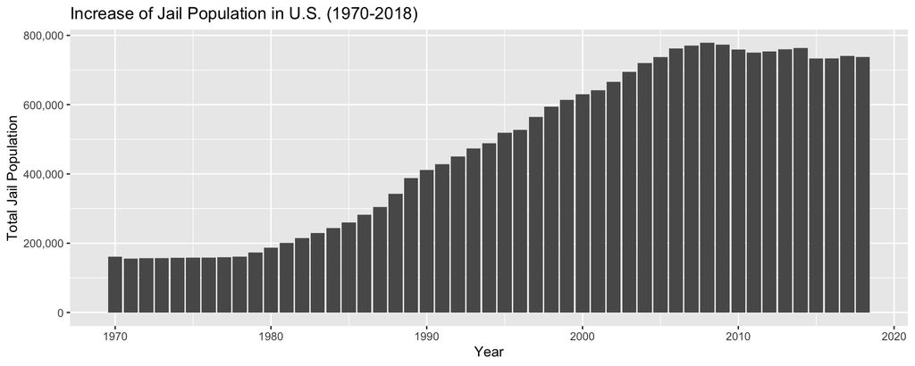

How has America’s prison population grown in the aftermath of the “tough on crime” era? This graph depicts a significant increase in the prison population since the mid-1970s. There is a clear increase that begins that the start of the “tough on crime” era. From 1990 to 2010, incarceration rates skyrocketed.

## Section 4: Growth of Prison Population by State

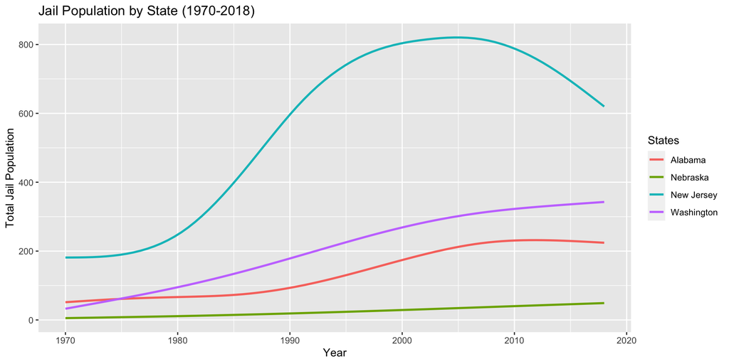

The selected four states represent the four US regions specified by the Vera Project. Each state had distinct trends in prison population growth. This suggests that the “tough on crime” era functioned differently at the state level. New Jersey’s new incarcerations skyrocketed at the height of this era but, along with Alabama, declined in the aftermath. Nebraska and Washington, on the other hand, are still steadily increasing in total prison populations.

## Section 5: Pretrial Jailing Rate Inequality by Urbanicity

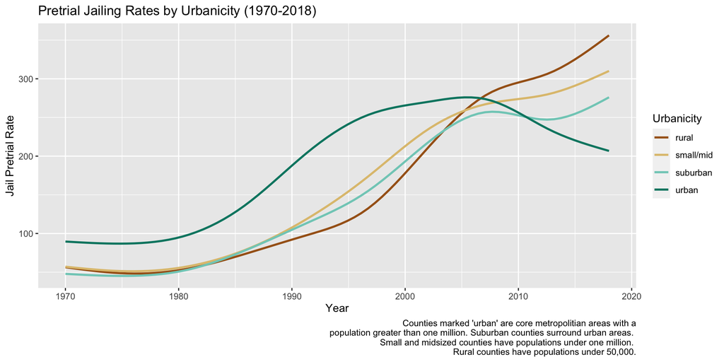

How did rural and urban counties differ in pretrial jailing rates after the turn of the century? While urban pretrial jailing has decreased since the 2000s, pretrial jailing in rural counties has continued to increase. The policy changes over the last two decades have had distinct impacts depending on urbanicity.

## Section 6: Pretrial Jail Bookings by State

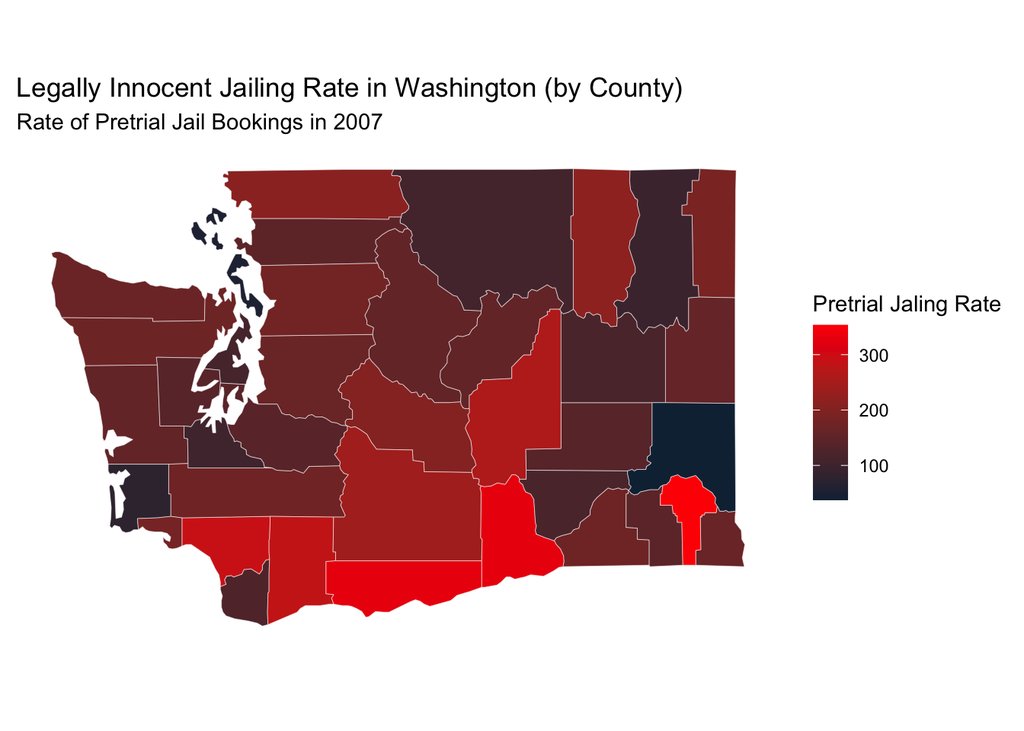

A speedy trial requires resources. In Washington state, rural states have particularly high pretrial jailing rates. This map suggests that rural counties lack the infrastructure necessary to support an effective justice system. In 2007, the aftermath of the “tough on crime” was still roaring on. This map illuminates how the aftermath played out at the county level.